# FigureYa49 AS_3rd

小丫画图出品

10/21/2018

微信ID: epigenomics E-mail: epigenomics@rainbow-genome.com

本代码作者：徐洲更https://www.jianshu.com/u/9ea40b5f607a

[figure not shown]

小丫编辑校验

### 需求描述

现在最流行的三代测序里面必定要分析的可变剪切，用IGV获得sashimi图，定量地展示可变剪切情况。

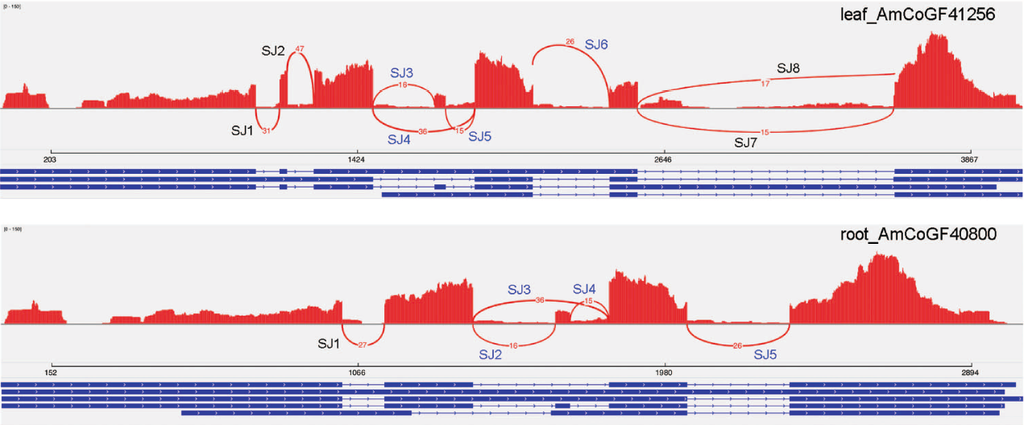

Sashimi

出自：https://www.nature.com/articles/celldisc201731/

图解：外显子上的比对以密度图的形式展示（图中红色部分）

### 适用范围

1. 要求有三代全长转录组和二代转录组数据
2. 三代无参转录组展示基因的可变剪切
3. Linux操作系统

## 前期准备

### 软件准备

请确保运行系统是Linux，且软件都是通过bioconda进行安装或者在环境变量中，否则运行脚本时会出错

HISAT2: 用于二代RNA-seq序列比对

```bash
conda install -c bioconda hisat2
```

GMAP: 用于比对三代全长转录本

```bash
conda install -c bioconda gmap
```

gffread: 用于GFF文件的格式转换

```bash
conda install -c bioconda gffread
```

> 软件安装部分涉及到conda的使用，请自行搜索教程学习，我在[生信必修课之软件安装](https://ke.qq.com/course/310838?_bid=167&_wv=3)的06学会包管理工具安装一节也有详细的讲解。

### 数据准备

- 数据来源：https://www.nature.com/articles/celldisc201731/
- 数据要求：

一：FASTA格式的三代测序的全长唯一转录本模型(full-length UniTransModels)，类似于参考基因组，处理流程如下所示：

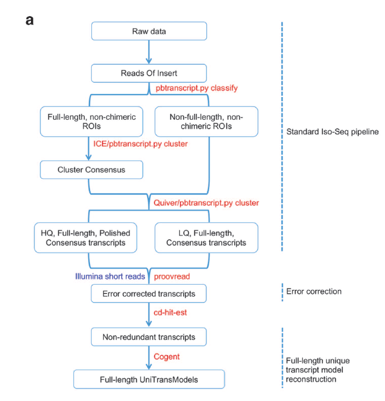

处理流程

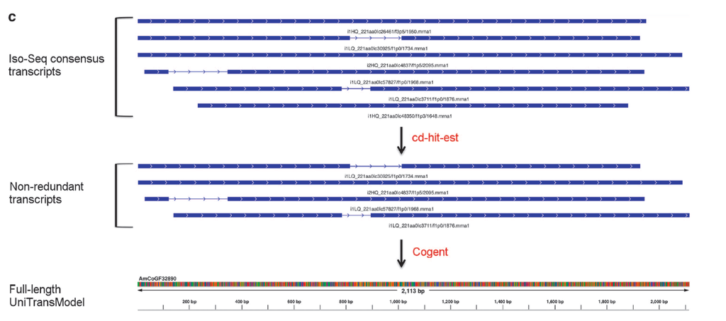

UniTransModel

Cogent分析见[三代转录组系列：使用Cogent重建基因组编码区](https://www.jianshu.com/p/ddacf47e128e)

二：FASTA格式的转录亚型(isoform)。 使用GMAP/Minimap2将纠错后非冗余的转录本(也就是上面`cd-hist-est`处理后，Cogent处理前的的序列)回帖到UniTransModels，之后合并具有相同剪切位点(splicing junctions)，同一个UniTransModels下具有不同剪切位点的转录本就被认为是转录亚型(transcription isoforms)。

冗余isofroms合并见[Tutorial: Collapse redundant isoforms without genome](https://github.com/Magdoll/cDNA_Cupcake/wiki/Tutorial:-Collapse-redundant-isoforms-without-genome)

三：二代测序数据，用于对不同剪切事件进行定量。二代数据由于内容过大，请按照如下方法下载

```bash
mkdir raw-data
prefetch -O raw-data ERR706814
fasterq-dump -3 -O raw-data raw-data/ERR706814.sra
```

> 注1：目前PacBio Iso-seq无法用于定量, 必须要用到二代数据才行.

> 注2：关于`prefetch`和`fasterq-dump`的使用，请阅读[都8102年了，还用fastq-dump，快换fasterq-dump吧](https://www.jianshu.com/p/5c97a34cc1ad)和[Fastq-dump: 一个神奇的软件](https://www.jianshu.com/p/a8d70b66794c)

## 数据处理

请保证软件准备部分的软件都已经安装完毕，请拷贝“sashimi_prepare.sh”到你的数据集下，然后用`chmod 755 sashimi_prepare.sh`增加运行权限。

对于测试数据集，运行如下命令

```bash
./sashimi_prepare.sh leaf.UniTransModel.fa leaf.UniTransModel.isoforms.fa raw-data/ERR706814.sra_1.fastq raw-data/ERR706814.sra_2.fastq -t 100
```

那么它就会在当前生成用于作图的文件

- sashimi.gtf
- sashimi_flt.bam

具体使用方法：

```bash
sashimi_prepare.sh -p sashimi -t 10 ref.fa isoform.fa read_1.fq read_2.fq
    -t: threads #运行的线程数
    -p: output prefix # 输出文件的前缀名
ref.fa: 参考转录组
isoform.fa: 转录亚型
read_1.fq: Illumina Paired-end 1
read_2.fq: Illumina Paired-end 2
```

如果你想对脚本进行修改，那么你需要仔细阅读如下内容

### 获取GTF文件

首先建立参考转录组的索引

```bash
gmap_build -D index -d leaf leaf.UniTransModel.fa
```

然后将转录亚型回帖到参考转录组上，获取GFF3文件

```bash
gmap -t 10 -D index -d leaf -f gff3_gene leaf.UniTransModel.isoforms.fa > leaf_gene.gff3
```

将GFF3转成GTF格式

```bash
gffread leaf_gene.gff3 -T -o leaf_gene_tmp.gtf
sed -n '/exon/p' leaf_gene_tmp.gtf > leaf_gene.gtf
rm leaf_gene_tmp.gtf
```

关于GMAP的用法，请阅读[如何使用GMAP/GSNAP进行转录组序列比对](https://www.jianshu.com/p/3f331861c364)

### 构建BAM文件

为了后续进行展示，需要将二代数据回帖到参考转录组上

第一步：建立索引

```bash
hisat2-build -p 20 leaf.UniTransModel.fa index/leaf.UniTransModel
# -p 表示线程数
```

第二步：比对回参考转录组

```bash
hisat2 -x index/leaf.UniTransModel -1 raw-data/ERR706814.sra_1.fastq -2 raw-data/ERR706814.sra_2.fastq -p 100 | samtools sort -@ 50 > leaf_sort.bam &
```

第三步：去除低质量的比对read

```bash
samtools view -@ 10 -b -q 30 leaf_sort.bam > leaf_flt.bam
```

## IGV展示

### 软件安装

从[IGV官网](http://software.broadinstitute.org/software/igv/download)根据实际系统选择版本进行下载，解压后，Windows用户双击“igv.bat”运行。如果IGV无法正常运行，则需要安装JAVA运行环境，请到[Java官方下载点](https://www.oracle.com/technetwork/java/javase/downloads/index.html)选择Java SE 8u181或者 Java SE 10.0.2进行下载安装。

### 操作视频

见附件FigureYa49AS_3rd.mp4文件

视频所用数据集链接: 链接：https://share.weiyun.com/5jzlQak 密码：n6li5h

用IGV导出的SVG文件是矢量图，可以用Illustrator等软件编辑。

实际效果：

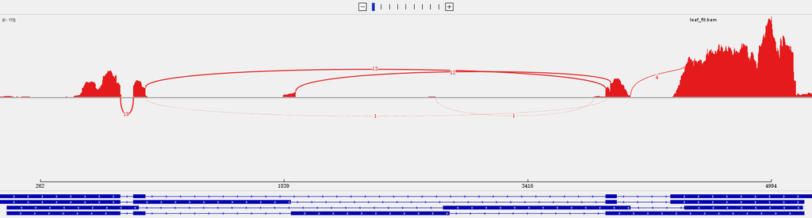

IGV截图